# GEOG 6000 Lab 08 Spatial Data in R

Simon Brewer and Blake Vernon

22 October, 2026

In this lab, we will explore some of R’s functionality with spatial data, with special attention given to the **sf** package. For more information about `sf`, you can visit their [website](https://r-spatial.github.io/sf/). Robin Lovelace’s book *Geocomputation with R* (available [online](https://geocompr.robinlovelace.net/)) is also a really helpful and educational source for learning **sf**. In fact, much of this lab is just an abbreviated version of that book. For some of the longer examples, it is highly recommended to use R’s scripting functions to run the examples to save on re-typing.

Before starting the lab, you will need to set up a new folder for your working directory. Go to your `geog6000` folder now and create a new folder for today’s class called `lab08`. The following files will be used in this lab, all available on Canvas:

- Climate dataset for Western North America: *WNAclimate.csv*
- Temperature dataset for Oregon in shapefile format: *oregon.zip*
- New York state polygon data in a shapefile: *NY_Data.zip*
- Digital elevation map from Switzerland: *swiss_dem.grd*
- A shapefile of California places: *ca_places.zip*
- A Landsat 8 scene from California: *rs.zip*

You will need to download these files from Canvas, and move them from your `Downloads` folder to the `data` folder that you made previously. Make sure to unzip the zip files so that R can access the content. Note that on Windows, you will need to right-click on the file and select ‘Extract files’.

You will also need to install the following packages:

```r
pkgs <- c("ggplot2",
          "raster",
          "RColorBrewer"
          "sf",
          "viridis")

install.packages(pkgs)
```

```r
library(ggplot2)
library(terra)
library(RColorBrewer)
library(sf)
library(viridis)
```

# Intro to `sf`

### What is `sf`?

`sf` is an R package designed to work with spatial data organized as “simple features” (hence, ‘sf’). Mostly, it supersedes the `sp` package (written by the same people), but it also collapses a lot of other R packages into one. In fact, just a few years ago, if you were to take this course, you would have loaded all of these packages:

```r
library(maptools)
library(rgdal)
library(rgeos)
library(sp)
```

Now, a simple

```r
library(sf)
```

will suffice. The `sf` package is able to provide all the functionality it does because it interfaces with three widely adopted programming standards: PROJ, GDAL, and GEOS. These provide for coordinate reference systems, reading and writing of spatial data, and geometric operations, respectively, but more on this in a moment.

Note that all `sf` functions are prefixed with `st_` (a legacy of this R package’s origins in PostGIS, where ‘st’ means “spatial type”).

### What is a simple feature?

A simple feature is, in the words of the `sf` authors, “a formal standard (ISO 19125-1:2004) that describes how objects in the real world can be represented in computers, with emphasis on the spatial geometry of these objects” ([ref](https://r-spatial.github.io/sf/articles/sf1.html)). In other words, its structured data that provides information about a location in space, including its shape.

The way that `sf` chooses to represent simple features in R should be familiar to you because they are just fancy data.frames. To demonstarte this, we’ll load a file of county outlines for North Carolina (this file is included when you install the `sf` package):

```r
path_to_data <- system.file("shape/nc.shp", package="sf")

north_carolina <- st_read(path_to_data, quiet = TRUE)

north_carolina <- north_carolina[ , c("CNTY_ID", "NAME", "AREA", "PERIMETER")]

north_carolina
```

```
## Simple feature collection with 100 features and 4 fields
## Geometry type: MULTIPOLYGON
## Dimension:     XY
## Bounding box:  xmin: -84.32385 ymin: 33.88199 xmax: -75.45698 ymax: 36.58965
## Geodetic CRS:  NAD27
## First 10 features:
##    CNTY_ID        NAME  AREA PERIMETER                       geometry
## 1     1825        Ashe 0.114     1.442 MULTIPOLYGON (((-81.47276 3...
## 2     1827   Alleghany 0.061     1.231 MULTIPOLYGON (((-81.23989 3...
## 3     1828       Surry 0.143     1.630 MULTIPOLYGON (((-80.45634 3...
## 4     1831   Currituck 0.070     2.968 MULTIPOLYGON (((-76.00897 3...
## 5     1832 Northampton 0.153     2.206 MULTIPOLYGON (((-77.21767 3...
## 6     1833    Hertford 0.097     1.670 MULTIPOLYGON (((-76.74506 3...
## 7     1834      Camden 0.062     1.547 MULTIPOLYGON (((-76.00897 3...
## 8     1835       Gates 0.091     1.284 MULTIPOLYGON (((-76.56251 3...
## 9     1836      Warren 0.118     1.421 MULTIPOLYGON (((-78.30876 3...
## 10    1837      Stokes 0.124     1.428 MULTIPOLYGON (((-80.02567 3...
```

You can summarize this somewhat verbose printout by noting that simple features fit a simple formula:

$$sf = attributes + geometry + crs$$

This formula also sugests the kinds of ways that you might interact with an `sf` object by, for example, changing its crs, or filtering based on its attributes (or geometry), or manipulating its geometry.

##### **Attributes**

*Attributes* are properties of a feature. In this case, the features are counties in North Carolina, and their attributes are things like name and area. In an `sf` data.frame, **each feature is a row, and each attribute is a column**. In the `north_carolina` object, for example, the first feature has the name “Ashe” and its county ID is 1825.

##### **Geometry**

A very special attribute column is called the *geometry* (sometimes labeled ‘geom’ or ‘shape’). It consists of a point or set of points (specifically, their coordinates) that define the shape and location of the feature. The simple feature standard includes 17 geometry types, 7 of which are supported by `sf`: point, multipoint, linestring, multilinestring, polygon, multipolygon, and geometry collection.

As mentioned already, these geometries are just a series of points:

```r
point_one <- st_point(c(0, 3))

point_two <- st_point(c(5, 7))

a_line <- st_linestring(c(point_one, point_two))
```

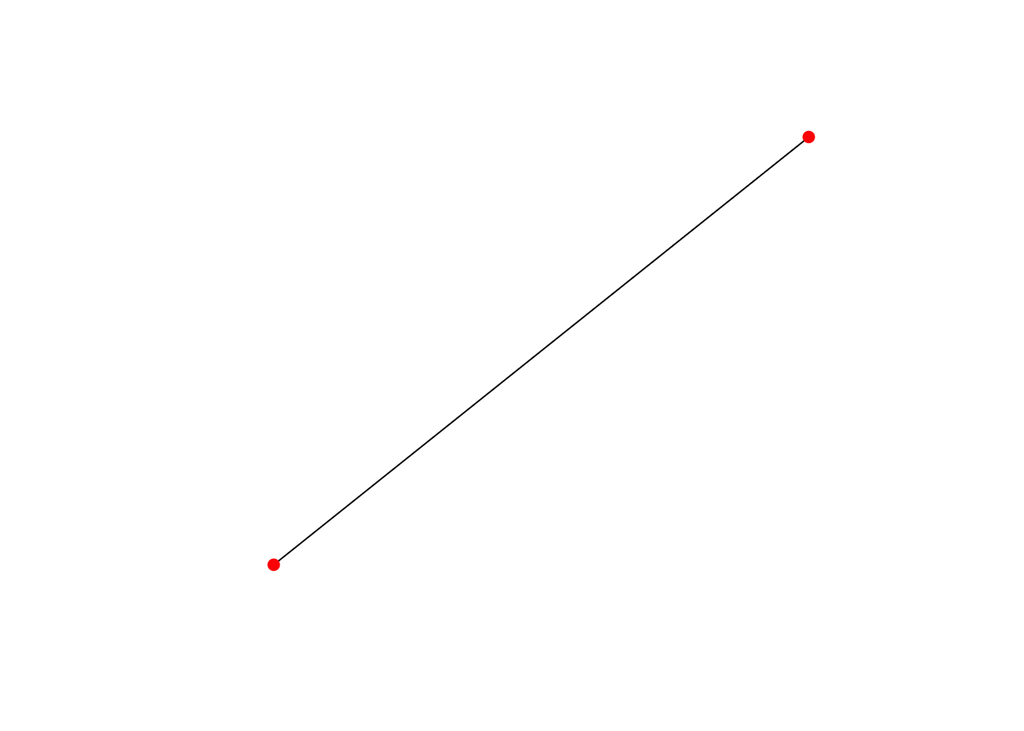

If you print these geometries

```r
point_one
```

```
## POINT (0 3)
```

```r
a_line
```

```
## LINESTRING (0 3, 5 7)
```

you see that they are represented as a text string. This is the [Well Known Text](https://en.wikipedia.org/wiki/Well-known_text_representation_of_geometry) (WKT) standard for specifying geometries. It tells us what kind of geometry the feature is and lists its x-y coordinates separated by commas.

If you want to know what geometry type your simple feature contains, try:

```r
st_geometry_type(a_line)
```

```
## [1] LINESTRING
## 18 Levels: GEOMETRY POINT LINESTRING POLYGON MULTIPOINT ... TRIANGLE
```

##### **CRS**

The final ingredient in a simple feature is its a spatial or [*coordinate reference system*](https://en.wikipedia.org/wiki/Spatial_reference_system) (CRS). A CRS provides two crucial pieces of information: (i) what rule we use to assign coordinates to points and (ii) what datum to use. It is not an exaggeration to say that **the CRS is the most important element of a simple feature**, for without a CRS, the numbers in the geometry column are just that, numbers, rather than full-blooded *spatial* coordinates.

Understanding what a coordinate assignment rule does is beyond the scope of this lab, but the datum deserves some attention. In effect, it specifies three things:

1. the origin or the point on the earth’s surface where the coordinates are `POINT (0 0)`,
2. the scale of the coordinates, for example, whether we should think of `POINT (5 7)` as being 5 *meters* east and seven *meters* north of the origin, or - worse - 5 *feet* east and 7 *feet* north, and
3. the orientation of the system, or which way is up?

As with the geometries, the standard for representing CRS is WKT, though the easiest way to identify a CRS is to use its EPSG code. To find the EPSG code for a CRS, you can visit this website: [spatialreference.org](https://spatialreference.org/).

The most widely used CRS is the World Geodetic System 84 (WGS 84, a geographic system) whose EPSG code is 4326:

```r
st_crs(4326)
```

```
## Coordinate Reference System:
##   User input: EPSG:4326
##   wkt:
## GEOGCRS["WGS 84",
##     ENSEMBLE["World Geodetic System 1984 ensemble",
##         MEMBER["World Geodetic System 1984 (Transit)"],
##         MEMBER["World Geodetic System 1984 (G730)"],
##         MEMBER["World Geodetic System 1984 (G873)"],
##         MEMBER["World Geodetic System 1984 (G1150)"],
##         MEMBER["World Geodetic System 1984 (G1674)"],
##         MEMBER["World Geodetic System 1984 (G1762)"],
##         MEMBER["World Geodetic System 1984 (G2139)"],
##         MEMBER["World Geodetic System 1984 (G2296)"],
##         ELLIPSOID["WGS 84",6378137,298.257223563,
##             LENGTHUNIT["metre",1]],
##         ENSEMBLEACCURACY[2.0]],
##     PRIMEM["Greenwich",0,
##         ANGLEUNIT["degree",0.0174532925199433]],
##     CS[ellipsoidal,2],
##         AXIS["geodetic latitude (Lat)",north,
##             ORDER[1],
##             ANGLEUNIT["degree",0.0174532925199433]],
##         AXIS["geodetic longitude (Lon)",east,
##             ORDER[2],
##             ANGLEUNIT["degree",0.0174532925199433]],
##     USAGE[
##         SCOPE["Horizontal component of 3D system."],
##         AREA["World."],
##         BBOX[-90,-180,90,180]],
##     ID["EPSG",4326]]
```

If you are familiar with the PROJ4-string syntax, you can retrieve that from a CRS with:

```r
st_crs(4326)$proj4string
```

```
## [1] "+proj=longlat +datum=WGS84 +no_defs"
```

However, current open standards specified by PROJ and GDAL discourage the use of PROJ4-string syntax in favor of WKT, so it is probably best to get use to the latter now.

##### **Bounding Box**

There’s actually one more element to a simple feature, but it is not as vital as the others and is really already implicit in the geometry. That is the bounding box. This is an object defined by the spatial extent of the data: the minimum and maximum x and y coordinates. You can retrieve the bounding box of a simple feature this way:

```r
st_bbox(north_carolina)
```

```
##      xmin      ymin      xmax      ymax
## -84.32385  33.88199 -75.45698  36.58965
```

There are myriad uses for the bounding box, though we need not dwell on them here.

# Read and Write

Reading and writing spatial data, it turns out, is quite the chore. The solution `sf` relies on is to interface with GDAL, which handles lots of different spatial data types (it’s kinda its whole purpose). Currently supported (vector) spatial data types can be found at [GDAL.org](https://gdal.org/drivers/vector/index.html). Perhaps the most common spatial data type - because ESRI is a thing - is the shapefile, which has a *.shp* file extension.

### Reading in spatial data

In `sf`, the function for reading in spatial data is `st_read`. Here is the nitty-gritty and, perhaps, needlessly verbose version first:

```r
NY8 <- st_read(dsn = "./data/NY_data/NY8_utm18.shp",
               layer = "NY8_utm18",
               drivers = "ESRI Shapefile")
```

```
## options:        ESRI Shapefile
```

`dsn` stands for “data source name” and specifies where the data is coming from, whether a file directory, a database, or something else. `layer` is the layer in the data source to be read in. Finally, `drivers` tells GDAL what format the file is in or what structure it has, so it knows how to correctly interpret the file. All of this information is printed to the console when you execute `st_read`.

In this case, we are using a simple ESRI shapefile, so the data source and layer are basically the same thing. Furthermore, `sf` is good at guessing the driver based on the file extension, so the driver does not normally need to be specified. Hence, we could just as well have written:

```r
NY8 <- st_read("./data/NY_data/NY8_utm18.shp")
```

And here’s what this looks like:

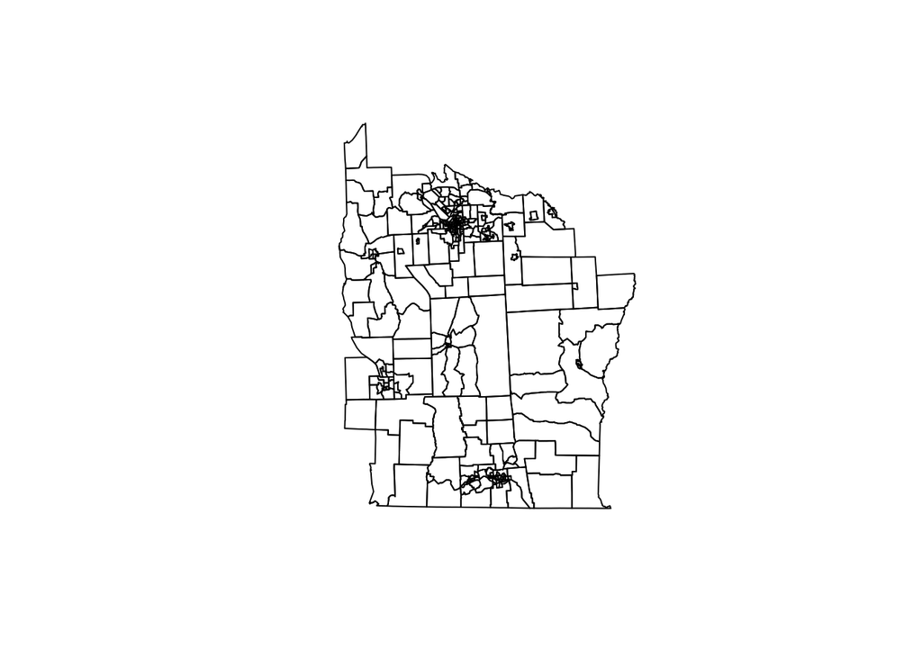

### Converting non-spatial data to simple features

Sometimes you have spatial data, but it is not in a spatial data format. Usually, this means you have a table or spreadsheet with columns for the x and y coordinates.

```r
wna_climate <- read.csv("./data/WNAclimate.csv")

head(wna_climate)
```

```
##   WNASEQ     LONDD   LATDD ELEV totsnopt annp Jan_Tmp Jul_Tmp
## 1      1 -107.9333 50.8736  686  78.7869  326   -13.9    18.8
## 2      2 -105.2670 55.2670  369 145.3526  499   -21.3    16.8
## 3      3 -102.5086 41.7214 1163  42.6544  450    -4.2    23.3
## 4      4 -110.2606 44.2986 2362 255.1009  489   -10.9    14.1
## 5      5 -114.1500 59.2500  880 164.8924  412   -23.9    14.4
## 6      6 -120.6667 57.4500  900 141.9260  451   -17.5    13.8
```

This can be converted to a simple feature using the `st_as_sf` function like so:

```r
wna_climate <- st_as_sf(wna_climate,
                        coords = c("LONDD", "LATDD"),
                        crs = 4326)

wna_climate
```

```
## Simple feature collection with 2012 features and 6 fields
## Geometry type: POINT
## Dimension:     XY
## Bounding box:  xmin: -138 ymin: 29.8333 xmax: -100 ymax: 60
## Geodetic CRS:  WGS 84
## First 10 features:
##    WNASEQ ELEV totsnopt annp Jan_Tmp Jul_Tmp                  geometry
## 1       1  686  78.7869  326   -13.9    18.8 POINT (-107.9333 50.8736)
## 2       2  369 145.3526  499   -21.3    16.8   POINT (-105.267 55.267)
## 3       3 1163  42.6544  450    -4.2    23.3 POINT (-102.5086 41.7214)
## 4       4 2362 255.1009  489   -10.9    14.1 POINT (-110.2606 44.2986)
## 5       5  880 164.8924  412   -23.9    14.4     POINT (-114.15 59.25)
## 6       6  900 141.9260  451   -17.5    13.8   POINT (-120.6667 57.45)
## 7       7 1100 183.4187  492   -18.8    13.2 POINT (-119.7167 56.7167)
## 8       8 1480 191.5657  606   -11.0    12.8    POINT (-114.6 50.7667)
## 9       9  651 144.9015  443   -22.4    15.3 POINT (-122.1667 59.5167)
## 10     10  725 151.0778  455   -23.5    15.4    POINT (-112.1 57.7667)
```

The function just needs to know what columns the x and y coordinates are in and what CRS they are specified in. And here’s what it looks like:

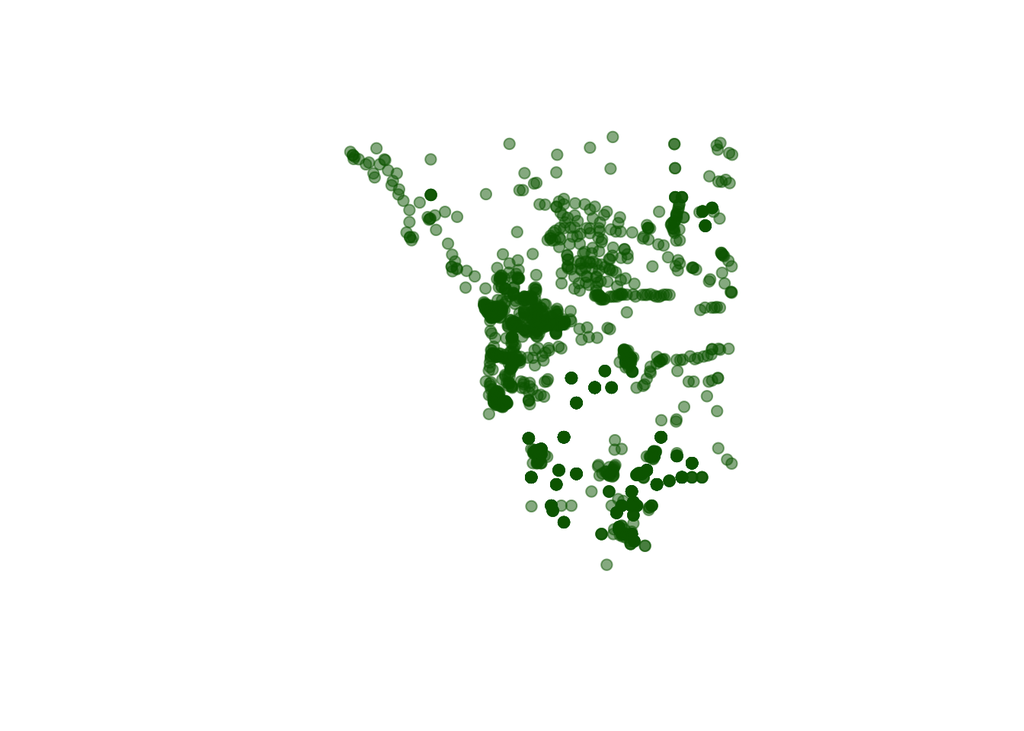

### Writing spatial data

The `sf` function for writing simple features to disk is `st_write`. It is almost an exact mirror of `st_read`, but it also requires that you specify the simple feature object in your R environment that you want to write to disk. If the layer already exists, you will need to specify `delete_layer = TRUE`.

```r
st_write(obj = wna_climate,
         dsn = "./data/wnaclim.shp",
         layer = "wnaclim",
         drivers = "ESRI Shapefile")
```

or, more simply:

```r
st_write(wna_climate, dsn = "./data/wnaclim.shp")
```

# CRS operations

**The cardinal rule for working with any spatial data is to make sure all of it is in the same CRS.** This ensures that any analysis which combines multiple sources is correctly comparing values at the same locations. Never ever ever ever do anything with your data until you are sure you’ve got the CRS right.

### Check CRS

The `st_crs()` function allows you to quickly chekck the CRS for any object.

```r
st_crs(NY8)
```

```
## Coordinate Reference System:
##   User input: WGS 84 / UTM zone 18N
##   wkt:
## PROJCRS["WGS 84 / UTM zone 18N",
##     BASEGEOGCRS["WGS 84",
##         DATUM["World Geodetic System 1984",
##             ELLIPSOID["WGS 84",6378137,298.257223563,
##                 LENGTHUNIT["metre",1]]],
##         PRIMEM["Greenwich",0,
##             ANGLEUNIT["degree",0.0174532925199433]],
##         ID["EPSG",4326]],
##     CONVERSION["UTM zone 18N",
##         METHOD["Transverse Mercator",
##             ID["EPSG",9807]],
##         PARAMETER["Latitude of natural origin",0,
##             ANGLEUNIT["Degree",0.0174532925199433],
##             ID["EPSG",8801]],
##         PARAMETER["Longitude of natural origin",-75,
##             ANGLEUNIT["Degree",0.0174532925199433],
##             ID["EPSG",8802]],
##         PARAMETER["Scale factor at natural origin",0.9996,
##             SCALEUNIT["unity",1],
##             ID["EPSG",8805]],
##         PARAMETER["False easting",500000,
##             LENGTHUNIT["metre",1],
##             ID["EPSG",8806]],
##         PARAMETER["False northing",0,
##             LENGTHUNIT["metre",1],
##             ID["EPSG",8807]]],
##     CS[Cartesian,2],
##         AXIS["(E)",east,
##             ORDER[1],
##             LENGTHUNIT["metre",1]],
##         AXIS["(N)",north,
##             ORDER[2],
##             LENGTHUNIT["metre",1]],
##     ID["EPSG",32618]]
```

You can also check the EPSG code (if specified):

```r
st_crs(NY8)$epsg
```

```
## [1] 32618
```

```r
st_crs(wna_climate)$epsg
```

```
## [1] 4326
```

And you can get the name of a CRS this way:

```r
format(st_crs(NY8))
```

```
## [1] "WGS 84 / UTM zone 18N"
```

### Set CRS

There are two methods to set the CRS for a spatial object: `st_crs<-` and `st_set_crs`.

```r
wna_climate <- st_set_crs(wna_climate, 4326)

st_crs(wna_climate) <- 4326

# st_crs(wna_climate)
```

Note: this should only be used when the simple feature is missing a CRS and you know what it is. It is **NOT** for *re-projecting* the sf object to a new coordinate system.

### Reprojecting CRS

The `st_transform()` function allows you to project your sf object to a new CRS. This is particularly useful if you have multiple data sources with different original coordinate systems.

```r
# st_crs(NY8)

NY8 <- st_transform(NY8, crs = 4326)

# st_crs(NY8)
```

As a reminder: when you read in spatial data, the first thing you should use is `st_crs` to check the CRS and `st_transform` to re-project if necessary.

# Attribute operations

The attribute part of a `sf` object is a data.frame, so you can use all the methods we have previously looked at for data manipulation in working with attributes.

```r
oregon_tann <- read_sf("./data/oregon/oregontann.shp")

class(oregon_tann)
```

```
## [1] "sf"         "tbl_df"     "tbl"        "data.frame"
```

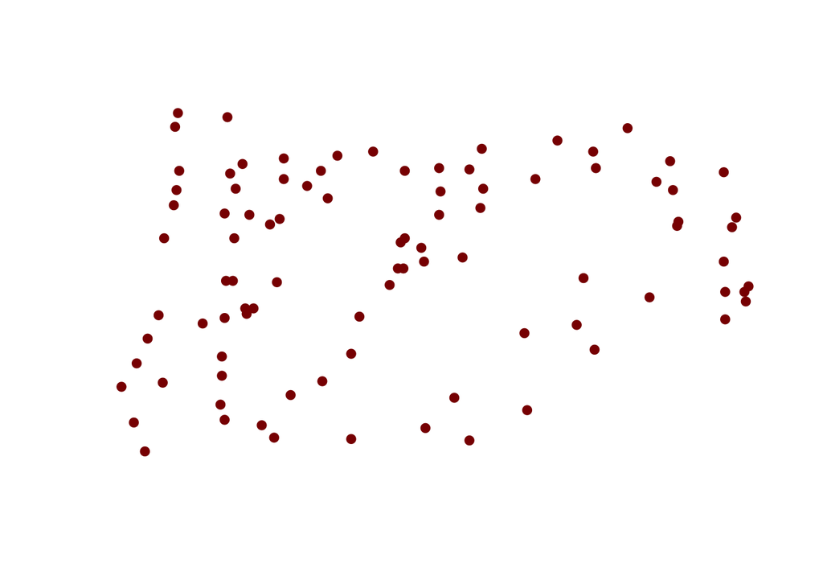

If you enter the name of an `sf` object, it will print the first few rows of the attribute table:

```r
oregon_tann
```

```
## Simple feature collection with 92 features and 4 fields
## Geometry type: POINT
## Dimension:     XY
## Bounding box:  xmin: -124.567 ymin: 42.05 xmax: -116.967 ymax: 46.15
## CRS:           NA
## # A tibble: 92 × 5
##    elevation  tann coords_x1 coords_x2          geometry
##        <int> <dbl>     <dbl>     <dbl>           <POINT>
##  1       846   9.6     -121.      44.9 (-120.717 44.917)
##  2        96  12.5     -120.      45.7   (-120.2 45.717)
##  3       543  11.1     -123.      42.2 (-122.717 42.217)
##  4         2  10.3     -124.      46.2  (-123.883 46.15)
##  5      1027   7.6     -118.      44.8 (-117.817 44.833)
##  6      1050   8.4     -118.      44.8 (-117.833 44.783)
##  7        24  10.8     -124.      43.1 (-124.383 43.117)
##  8      1097   7.7     -121.      44.1 (-121.317 44.067)
##  9       999   9.5     -118.      43.9 (-118.167 43.917)
## 10        18  11.2     -122.      45.6  (-121.95 45.633)
## # ℹ 82 more rows
```

### Select Columns

```r
# get elevation and tann columns

# method 1
oregon_tann2 <- oregon_tann[ , c("elevation", "tann")]

# method 2
oregon_tann2 <- subset(oregon_tann, select = c(elevation, tann))

names(oregon_tann)
```

```
## [1] "elevation" "tann"      "coords_x1" "coords_x2" "geometry"
```

```r
names(oregon_tann2)
```

```
## [1] "elevation" "tann"      "geometry"
```

Notice this very important difference between regular data.frames and `sf` data.frames: when you subset by columns, even though you do not explicitly state that you want to keep the geometry column, it keeps that column anyway. In this sense, the geometry column is said to be “sticky.”

### Filter Rows

Subsetting the data by rows works in the same way as before. So we can carry out conditional selection of locations by using the usual comparison operators (`<, <=, ==, !=, >=, >`). For example, to select only the points above 1000 m elevation in the Oregon data set:

```r
# get features above 1000 meters

# method 1
oregon_tann3 <- oregon_tann[oregon_tann$elevation > 1000, ]

# method 2
oregon_tann3 <- subset(oregon_tann, subset = elevation > 1000)
```

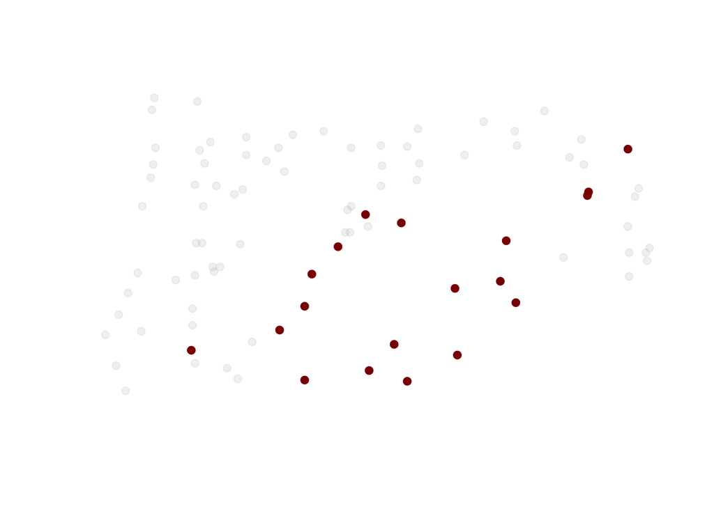

### Add Column

New variables can easily be appended to an existing `sf` object using the following notation:

```r
# method 1
oregon_tann$rando <- runif(n = nrow(oregon_tann))

# method 2
oregon_tann[, "rando"] <- runif(n = nrow(oregon_tann))

names(oregon_tann)
```

```
## [1] "elevation" "tann"      "coords_x1" "coords_x2" "geometry"  "rando"
```

### Extract Column

If you need to extract any variable from a `sf` object to a standard R vector, you can again use the standard notation. Note that if you use `[,]` to specify the columns, you need to add `drop = TRUE` to remove the geometry:

```r
# method 1
elevaton <- oregon_tann$elevation

# method 2
# if you don't specify drop = TRUE, it'll keep the sticky geometry column
elevation <- oregon_tann[ , "elevation", drop = TRUE]

elevation[1:10]
```

```
##  [1]  846   96  543    2 1027 1050   24 1097  999   18
```

### Get Geometry

If you need only the geometry (the set of coordinates, or vector definitions), these can be extracted as follows:

```r
# method 1
geometry <- st_geometry(oregon_tann)

# method 2
geometry <- oregon_tann$geometry

geometry
```

```
## Geometry set for 92 features
## Geometry type: POINT
## Dimension:     XY
## Bounding box:  xmin: -124.567 ymin: 42.05 xmax: -116.967 ymax: 46.15
## CRS:           NA
## First 5 geometries:
```

```
## POINT (-120.717 44.917)
```

```
## POINT (-120.2 45.717)
```

```
## POINT (-122.717 42.217)
```

```
## POINT (-123.883 46.15)
```

```
## POINT (-117.817 44.833)
```

### Drop Geometry

In case you just want the attributes, not the geometry:

```r
attributes <- st_drop_geometry(oregon_tann)

head(attributes)
```

```
## # A tibble: 6 × 5
##   elevation  tann coords_x1 coords_x2 rando
##       <int> <dbl>     <dbl>     <dbl> <dbl>
## 1       846   9.6     -121.      44.9 0.463
## 2        96  12.5     -120.      45.7 0.776
## 3       543  11.1     -123.      42.2 0.505
## 4         2  10.3     -124.      46.2 0.865
## 5      1027   7.6     -118.      44.8 0.580
## 6      1050   8.4     -118.      44.8 0.396
```

Note: this is actually a special sort of `data.frame` called a `tibble`. Not important to know about here, but does print slightly differently.

# Spatial operations

Spatial operations are like attribute operations, but they work with the geometry column rather than the attributes. There are loads of these functions, but will just review some of the more important ones here.

### Spatial Filter

This is probably the biggest one. Basically, you are taking one geometry and using it to filter other geometries. To demonstrate this, first we’ll make some random points in the `north_carolina` simple feature. Well, first-first, we need to project the simple features, since `sf` will protest if you try to do spatial operations on longitude and latitude, as several of these methods require the calculation of distances between locations.

```r
north_carolina <- st_transform(north_carolina, crs = 26918)
```

Now use `st_sample` to generate the random points:

```r
set.seed(1234)

random_pnts <- st_sample(north_carolina, size = 500)

random_pnts <- st_as_sf(random_pnts)
```

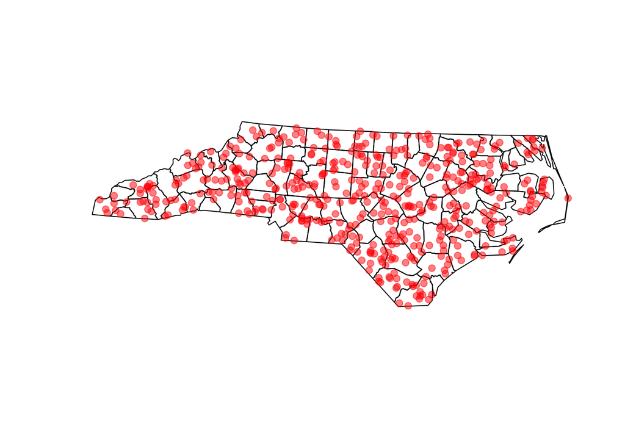

Now, we can use one geometry to filter out a second one. To obtain just the points in, say, Pasquotank County, we first subset the North Carolina `sf` object to extract only this county:

```r
pasquotank <- subset(north_carolina, NAME == "Pasquotank")
```

Then use the `st_filter()` function with the county polygon to get *only* the points located in that polygon:

```r
filtered_pnts <- st_filter(random_pnts, pasquotank)
```

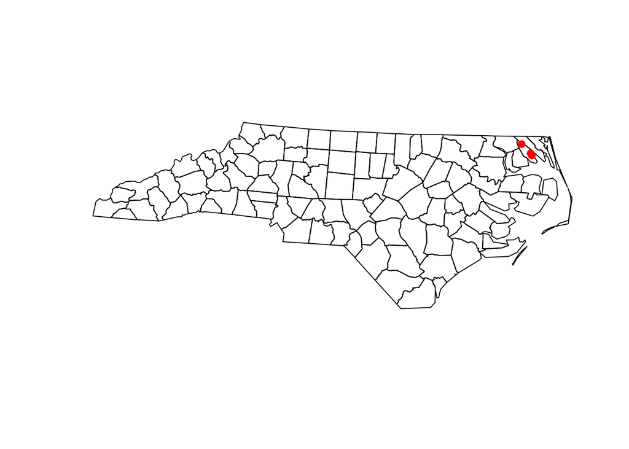

Now, you know where Pasquotank County is!

##### **Topological Relations**

Internally, `st_filter` assumes a “topological” or spatial relationship defined by what the `sf` authors refer to as spatial predicate (`.predicate`). By default, `st_intersects` works to find the geometry of one object located within another. We can, however, specify other spatial relationships. For example, to get all the points *outside* Pasquotank:

```r
filtered_pnts <- st_filter(random_pnts, pasquotank, .predicate = st_disjoint)
```

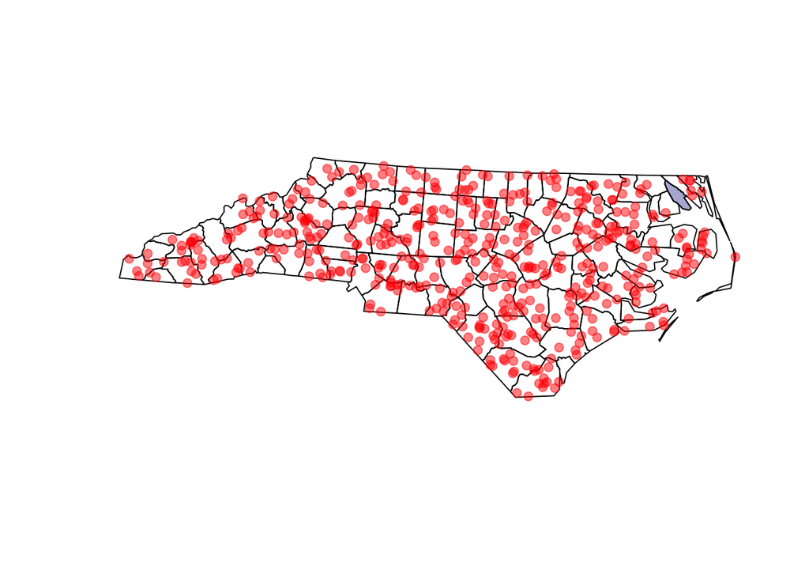

Another useful predicate is `st_is_within_distance`, which requires that you pass an additional distance (`dist`) argument to the filter. The `dist` argument is in units specified by the CRS, in this case meters.

```r
filtered_pnts <- st_filter(random_pnts,
                           pasquotank,
                           .predicate = st_is_within_distance,
                           dist = 50000)
```

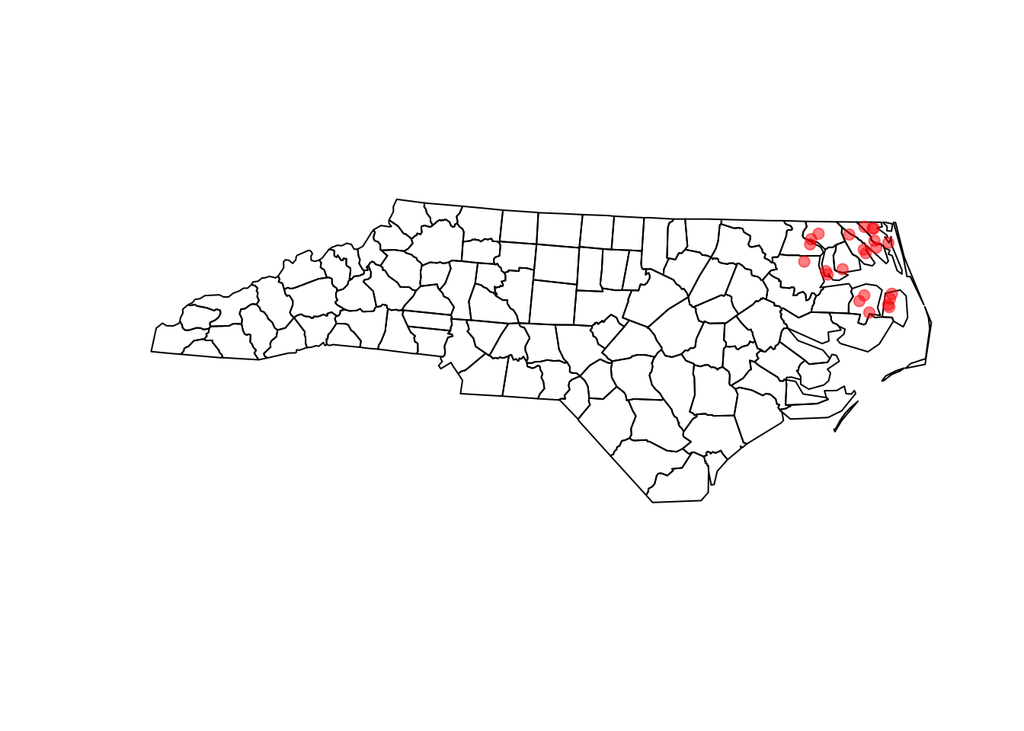

# Geometric operations

With spatial operations, the geometry is preserved (mostly). With geometric operations, the whole point is to manipulate the geometry. Again, we are just going to hit the highlights. It is worth emphasizing that **these operations will often behave differently depending on the geometry type**.

### Centroid

```r
the_heart_of_pasquotank <- st_centroid(pasquotank)
```

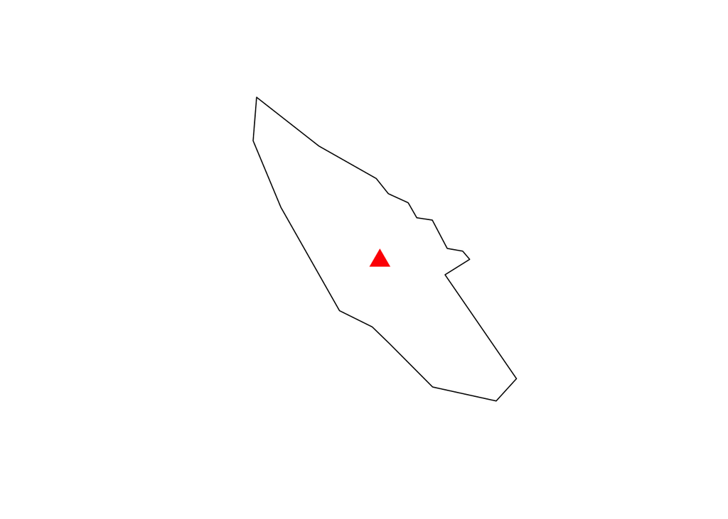

### Buffer

```r
the_heft_of_pasquotank <- st_buffer(pasquotank, dist = 50000)
```

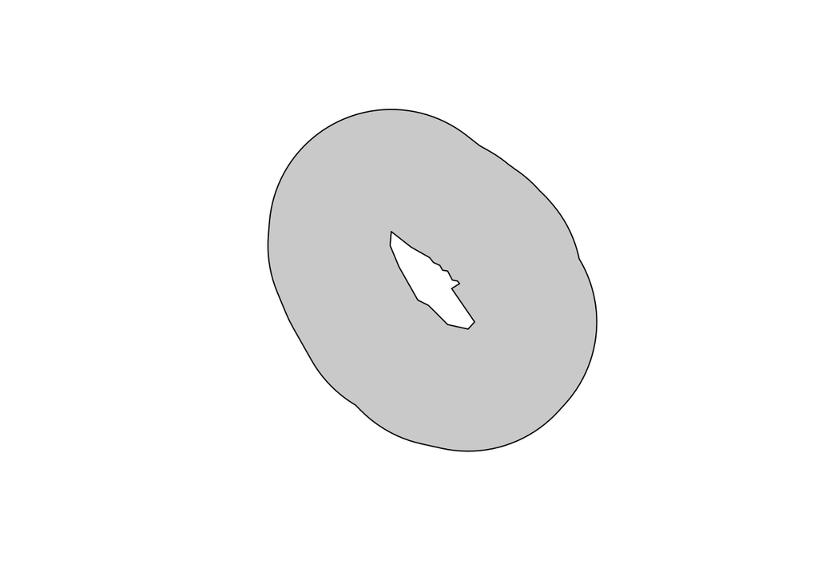

### Union

This one merges geometries and dissolves interior borders when applied to polygons.

```r
north_carolina_boundary <- st_union(north_carolina)
```

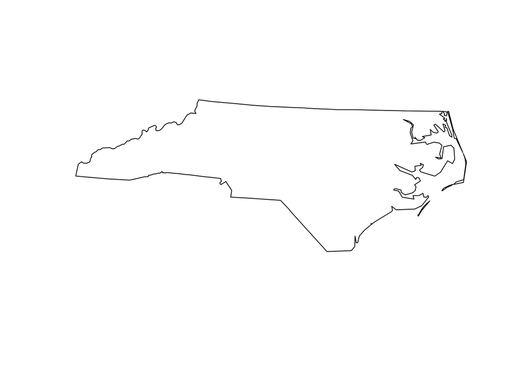

### Cast

To cast a geometry is to change it from one geometry type to another. For example, to convert the boundary of North Carolina to points (the vertices of the polygon):

```r
north_carolina_points <- st_cast(north_carolina_boundary, "POINT")
```

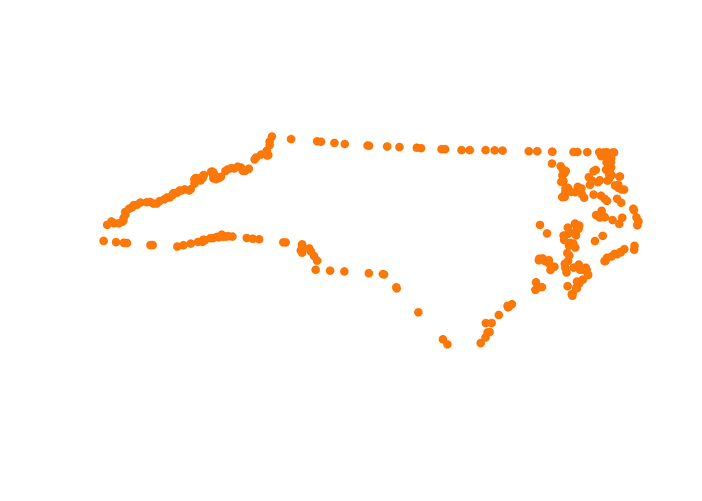

If we convert to a `LINESTRING` objcet, this acts to separate out the individual polygons:

```r
north_carolina_lines <- st_cast(north_carolina_boundary, "MULTILINESTRING")

north_carolina_lines <- st_cast(north_carolina_lines, "LINESTRING")
```

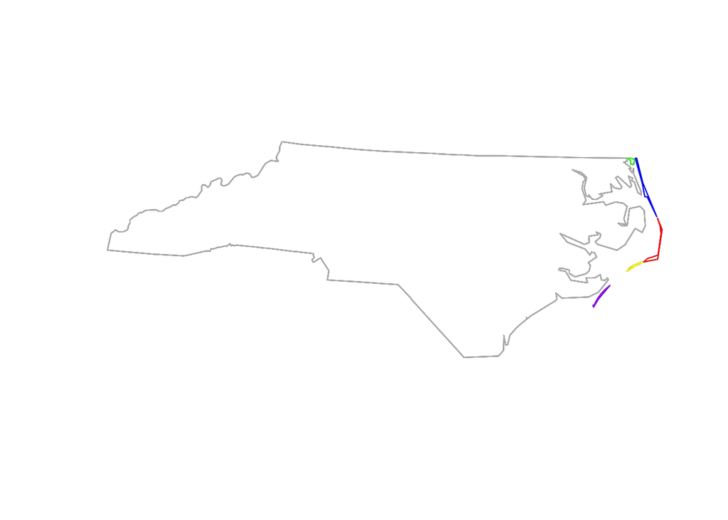

If you can’t tell, it was broken into six lines: one for the mainland, and the other five for the ecological (and cultural) disaster known as the Outer Banks.

# Plotting

### `graphics`

To make simple plots of an `sf` object, you can use R’s base function `plot()`:

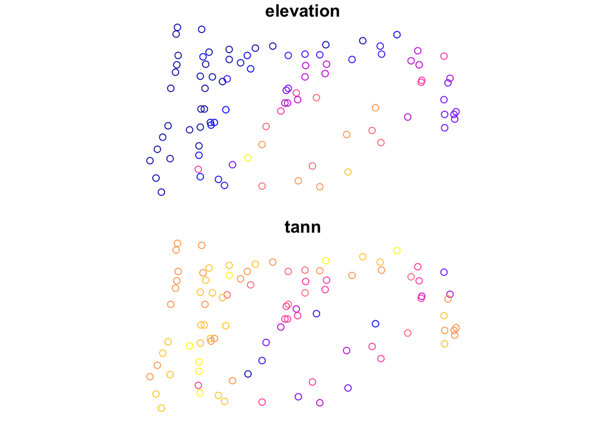

```r
plot(oregon_tann2)
```

Notice that it creates separate plots for each attribute. If you would prefer to plot the geometry itself, you have to say so explicitly.

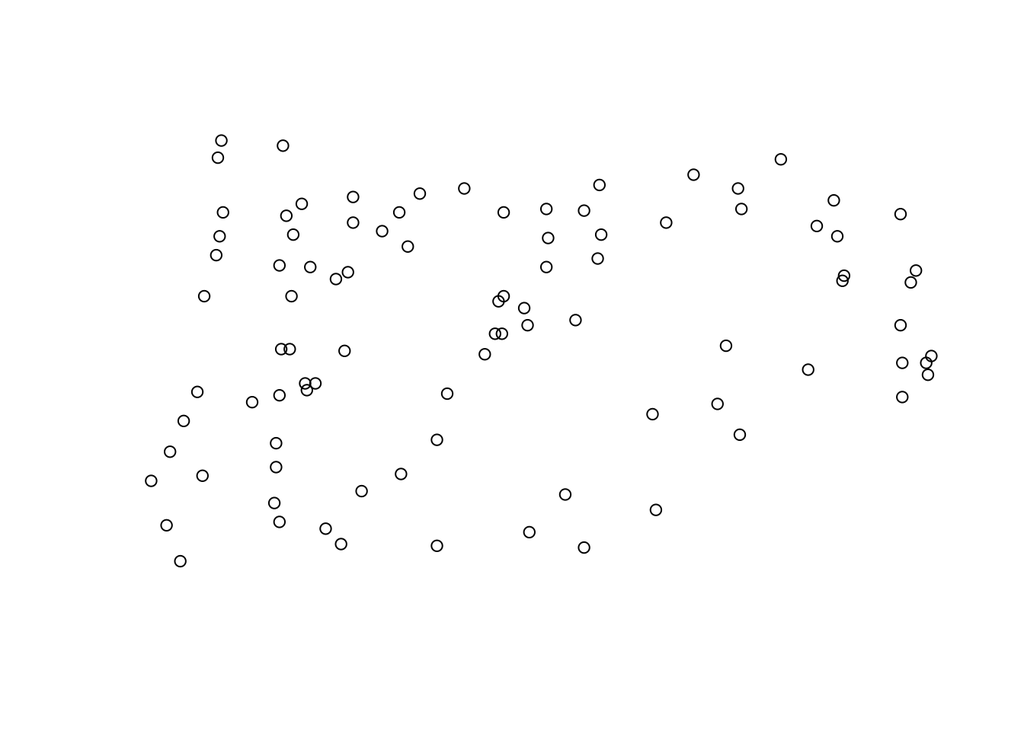

```r
plot(st_geometry(oregon_tann2))
```

### `ggplot2`

One of the easiest ways to improve on these base plots is to use **ggplot2**. This contains a a special plotting geometry, `geom_sf`, designed to work with `sf` objects. Here, we’ll use a subset of polygons from the `NY8` data to illustrate how this works. (Note that `geom_sf` refers to a **ggplot2** geometry, not a `sf` geometry.)

```r
binghamton <- subset(NY8, AREANAME == "Binghamton city")
```

We can now plot this by calling the `ggplot()` function and adding the `sf` object with `geom_sf`:

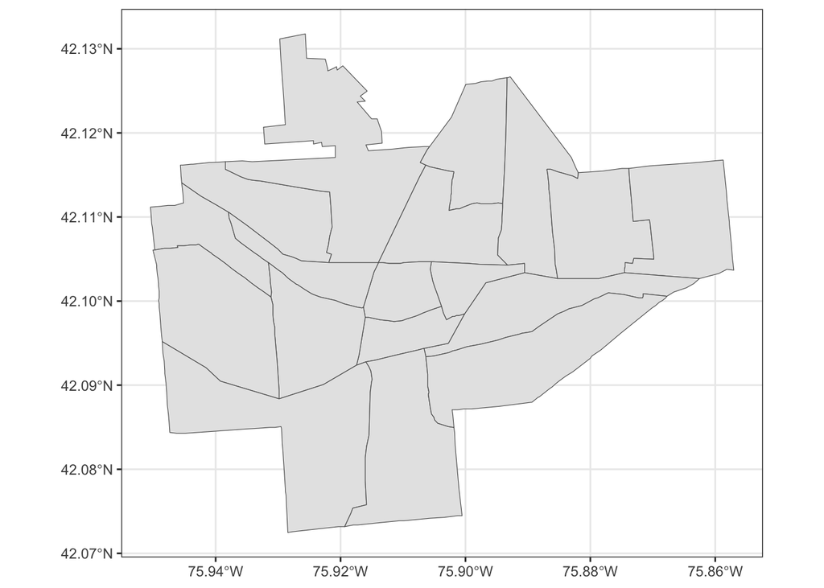

```r
ggplot() +
  geom_sf(data = binghamton) +
  theme_bw()
```

##### **Multiple Geometries**

Multiple layers can be added to a plot by adding additional `geom_sf` functions. Here, we first create a new `sf` object containing Binghamton and it’s neighboring polygons, then create some random points for plotting. As an aside here - there is an issue with the NY8 shapefile (a couple of the vertices are not correctly defined). As we are not doing anything topological with this right now, we can skip the checks on this (this is the first two lines of this code)

```r
sf_use_s2(FALSE)
NY8 <- st_make_valid(NY8)

bingies_neighbors <- st_filter(NY8, binghamton)

random_pnts <- st_sample(bingies_neighbors, size = 25)

random_pnts <- st_as_sf(random_pnts)
```

Now we can plot these: first the larger set of polygons, then Binghamton City and finally the points:

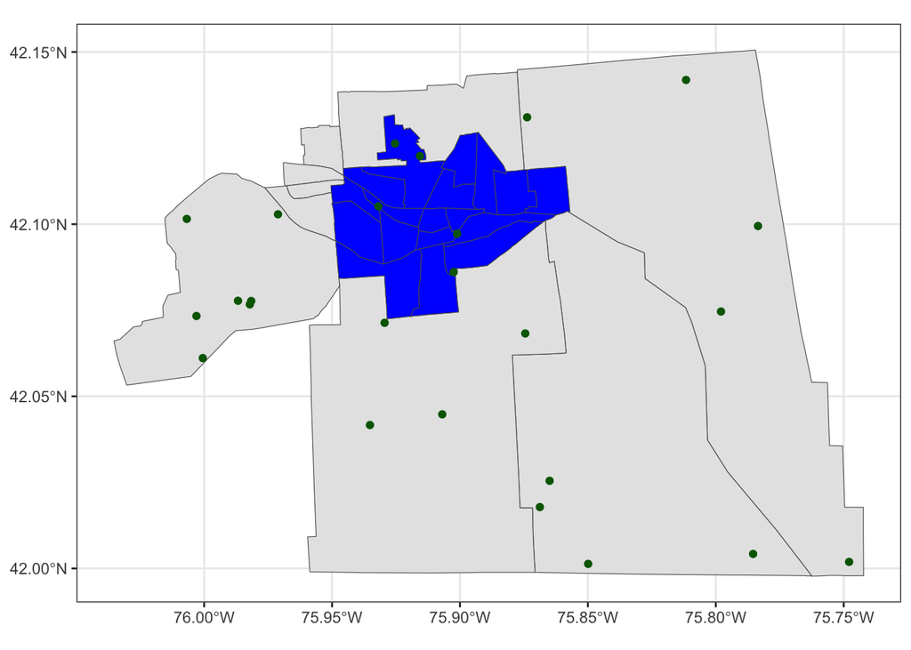

```r
ggplot() +
  geom_sf(data = bingies_neighbors) +
  geom_sf(data = binghamton, fill = "blue") +
  geom_sf(data = random_pnts, color = "darkgreen") +
  theme_bw()
```

##### **Plotting attributes**

We can create thematic maps by specifying the name of a variable in the `geom_sf()` function:

```r
names(binghamton)
```

```
##  [1] "AREANAME"   "AREAKEY"    "X"          "Y"          "POP8"
##  [6] "TRACTCAS"   "PROPCAS"    "PCTOWNHOME" "PCTAGE65P"  "Z"
## [11] "AVGIDIST"   "PEXPOSURE"  "Cases"      "Xm"         "Ym"
## [16] "Xshift"     "Yshift"     "geometry"
```

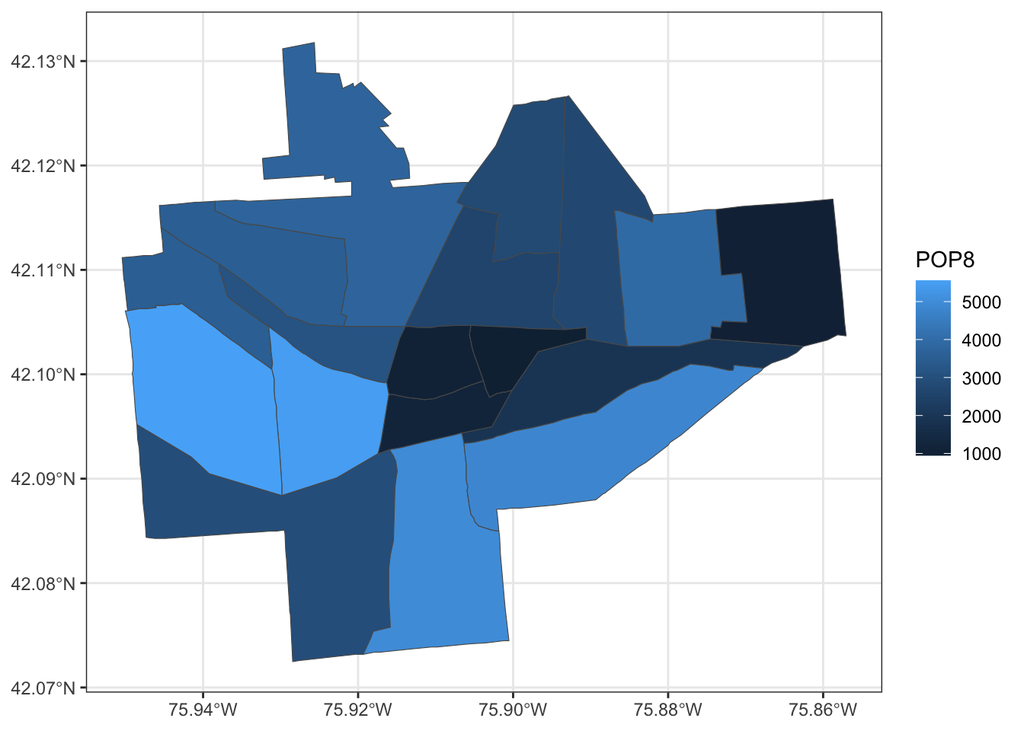

```r
ggplot() +
  geom_sf(data = binghamton, aes(fill = POP8)) +
  theme_bw()
```

##### **Manual Color Scale**

Here, we will use the `viridis` color scale, which is colorblind safe. This comes with several color palette `options`.

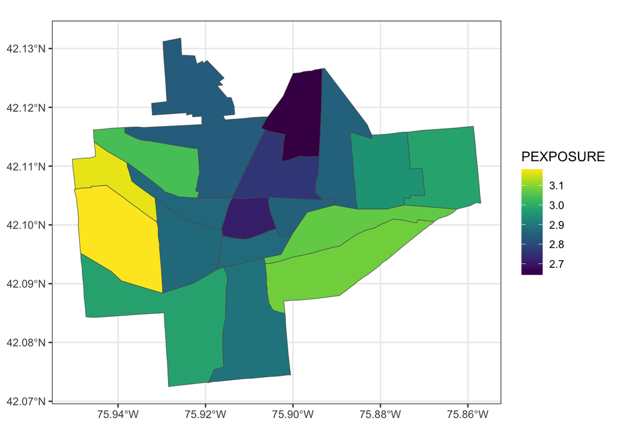

```r
ggplot() +
  geom_sf(data = binghamton, aes(fill = PEXPOSURE)) +
  scale_fill_viridis(option = "viridis") +
  theme_bw()
```

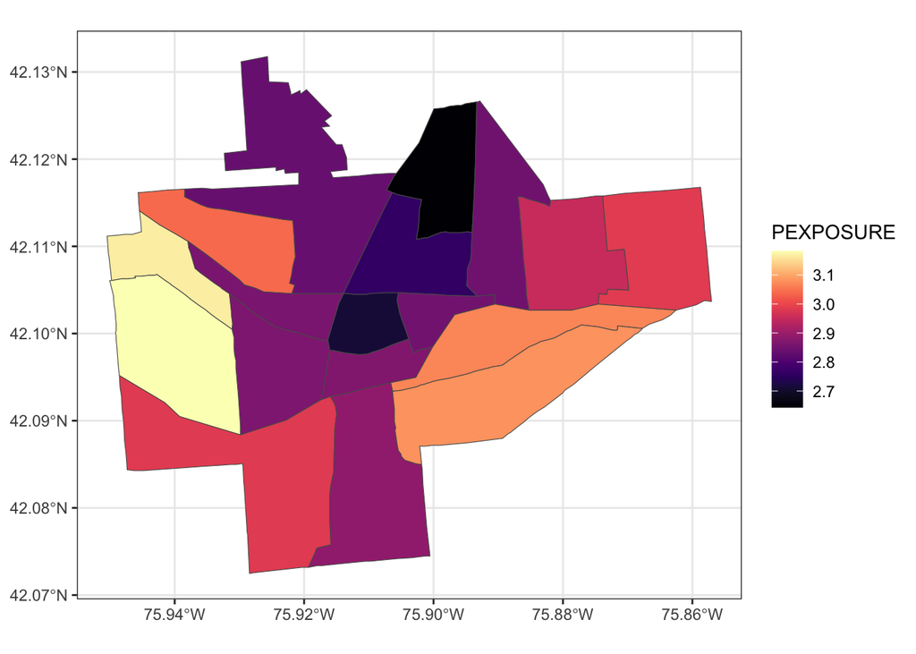

```r
ggplot() +
  geom_sf(data = binghamton, aes(fill = PEXPOSURE)) +
  scale_fill_viridis(option = "magma") +
  theme_bw()
```

##### **Coordinates**

By default, `geom_sf` transforms all `sf` objects to WGS84 (or latitude and longitude), but you can change this with `coord_sf`. This takes an argument `datum` that can be used to specify a different projection. Here we plot the Binghamton data using a UTM projection (zone 18N = EPSG code 26918). Note the change in both the projection of the data, and the axes:

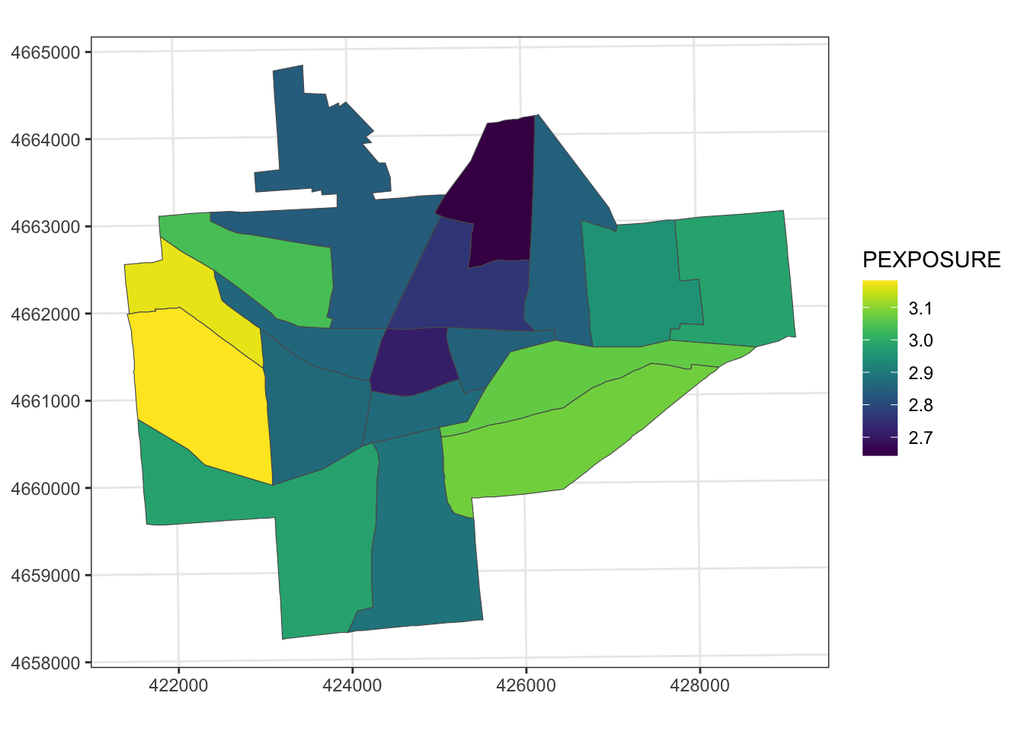

```r
ggplot() +
  geom_sf(data = binghamton, aes(fill = PEXPOSURE)) +
  scale_fill_viridis(option = "viridis") +
  coord_sf(datum = 26918) +
  theme_bw()
```

You can also use this to zoom in on different parts of the map.

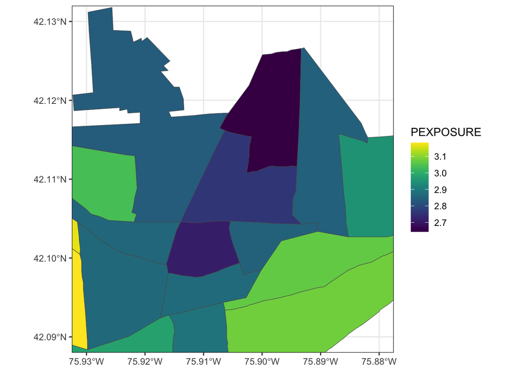

```r
ggplot() +
  geom_sf(data = binghamton, aes(fill = PEXPOSURE)) +
  scale_fill_viridis(option = "viridis") +
  coord_sf(xlim = c(-75.93, -75.88), ylim = c(42.09, 42.13)) +
  theme_bw()
```

# Raster data

Previously, we were working with *vector* spatial data. These are geometries composed of points defined by their coordinates. An alternative form of spatial data is known as a *raster*. This is gridded data. It takes the form of a rectangle composed of squares of equal size, which are sometimes called ‘cells’ or ‘pixels’. Each cell stores some kind of value.

This simplifies the geometry, which can be specified by two pieces of information: the spatial extent of the raster and the resolution of the cells. Here we create a blank raster with 10 rows and 10 columns, with a resolution of 10x10 using the `rast()` function. We then assign random values to each cell:

```r
r <- rast(nrow = 10, ncol = 10,
          xmin = 0, xmax = 100,
          ymin = 0, ymax = 100)

r[] <- runif(n = 100)

r
```

```
## class       : SpatRaster
## size        : 10, 10, 1  (nrow, ncol, nlyr)
## resolution  : 10, 10  (x, y)
## extent      : 0, 100, 0, 100  (xmin, xmax, ymin, ymax)
## coord. ref. :
## source(s)   : memory
## name        :    lyr.1
## min value   : 0.012609
## max value   : 0.984474
```

`rast` objects can be plotted using the base `plot()` command:

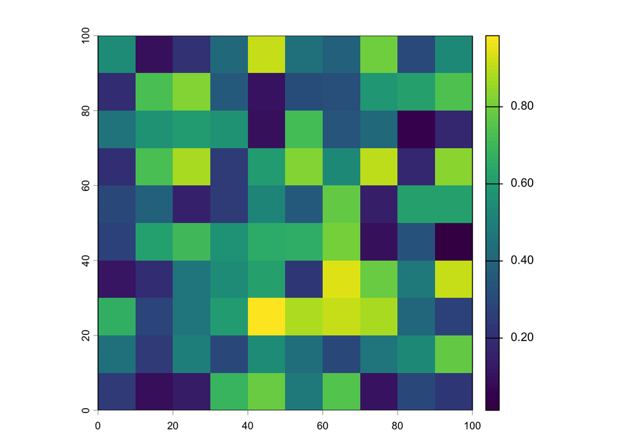

```r
plot(r)
```

The **terra** package offers a wide array of functions for dealing with gridded data, including the ability to read from many widely used file formats, like remote sensing images (e.g. GeoTiffs), NetCDF, and HDF formats. We will use it here to work with a Landsat 8 scene collected on June 14, 2017. The subset covers the area between Concord and Stockton, in California, USA. The files are contained in the zip file *rs.zip*. Download this (if you haven’t already) and unzip it in your `data` folder.

We will also need the shapefile of California places (*ca_places.zip*), so download and unzip this as well. We’ll read this in before starting:

```r
ca_places <- st_read("./data/ca_places/ca_places.shp", quiet = TRUE)
```

## Read and Write Rasters

To read in gridded data, use the `rast()` function. This will read in the Near Infrared (NIR) channel (`B5`)

```r
b5 <- rast("./data/rs/LC08_044034_20170614_B5.tif")

b5
```

```
## class       : SpatRaster
## size        : 1245, 1497, 1  (nrow, ncol, nlyr)
## resolution  : 30, 30  (x, y)
## extent      : 594090, 639000, 4190190, 4227540  (xmin, xmax, ymin, ymax)
## coord. ref. : WGS 84 / UTM zone 10N (EPSG:32610)
## source      : LC08_044034_20170614_B5.tif
## name        : LC08_044034_20170614_B5
## min value   :                0.000846
## max value   :                1.012432
```

When we print the `rast` object created, the second line of the output lists the dimensions of the data. Note that here, this has 1245 rows, 1497 columns and 1 layer. This also shows the resolution (30x30 m), the extent, the CRS and the a brief summary of the data.

```r
writeRaster(b5,
            filename = "./b5.tif",
            overwrite = TRUE)
```

## Raster CRS

As with the `sf` objects, we can check the coordinate reference system of the file we just read. This does not print very well, but if you look at the end you’ll see a reference to the EPSG code (32610).

```r
crs(b5)
```

```
## [1] "PROJCRS[\"WGS 84 / UTM zone 10N\",\n    BASEGEOGCRS[\"WGS 84\",\n        DATUM[\"World Geodetic System 1984\",\n            ELLIPSOID[\"WGS 84\",6378137,298.257223563,\n                LENGTHUNIT[\"metre\",1]]],\n        PRIMEM[\"Greenwich\",0,\n            ANGLEUNIT[\"degree\",0.01745329251…
```

If the CRS is not set, you can set it using the `crs()` function and an EPSG code. For example, the following code would set the CRS to WGS84 (**don’t run this as the CRS is already defined**)

```r
crs(b5) <- "EPSG:4326"
```

Again, this should not be used to *change* the CRS, only set it. Note that `crs` is for `rast` objects, `st_crs` for vectors.

You can transform the CRS for a raster layer using `project()`. This can again use a EPSG type code.

```r
b5_wgs84 <- project(b5, "EPSG:4326")

crs(b5_wgs84)
```

```
## [1] "GEOGCRS[\"WGS 84\",\n    DATUM[\"World Geodetic System 1984\",\n        ELLIPSOID[\"WGS 84\",6378137,298.257223563,\n            LENGTHUNIT[\"metre\",1]]],\n    PRIMEM[\"Greenwich\",0,\n        ANGLEUNIT[\"degree\",0.0174532925199433]],\n    CS[ellipsoidal,2],\n        AXIS[\"geodetic latitu…
```

We’ll keep the Landsat data in its UTM projection (10N), and reproject the CA place data to match:

```r
ca_places <- st_transform(ca_places, 32610)
```

## Basic Plotting

You can make a simple plot using the `plot()` function:

[figure not shown]

```r
plot(b5, main = "Landsat 8 (B2)")

plot(st_geometry(ca_places), add = TRUE)
```

## Summary Statistics

```r
global(b5, mean)
```

```
##                              mean
## LC08_044034_20170614_B5 0.2693644
```

```r
global(b5, sd)
```

```
##                               sd
## LC08_044034_20170614_B5 0.111683
```

## Subset Rasters

If we want to use only a subset of the original raster layer, the function `crop()` will extract only the cells in a given region. This can be defined using another raster object or Spatial* object, or by defining an `extent` object:

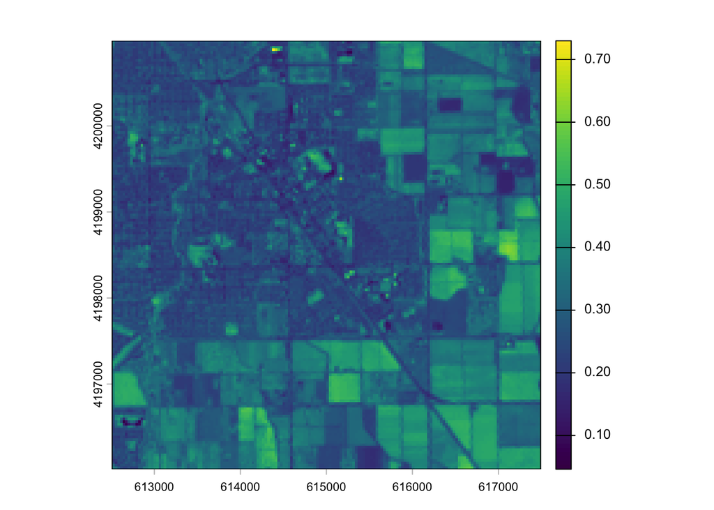

```r
# extent method
my_ext <- ext(c(xmin = 612500,
                    xmax = 617500,
                    ymin = 4196000,
                    ymax = 4201000))

b5_sub <- crop(b5, my_ext)

plot(b5_sub)
```

We can also use an `sf` object to crop the data. Here, we’ll extract the polygon for Bethel Island from the `ca_places` object, and use this to crop the raster:

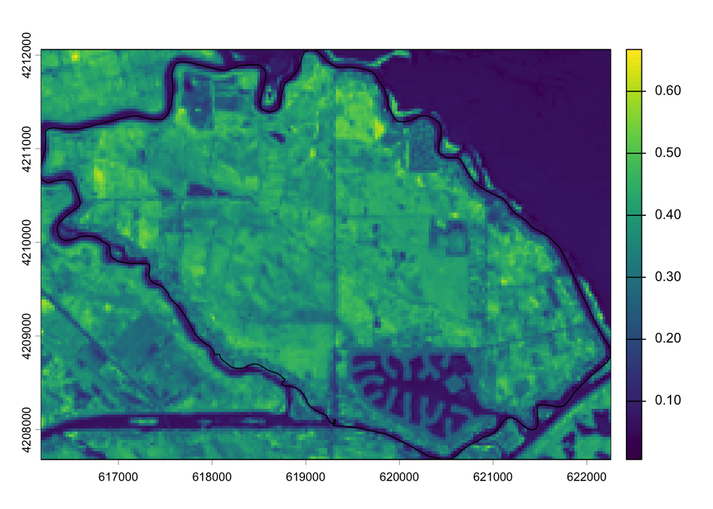

```r
bethel = subset(ca_places, NAME == "Bethel Island")

b5_sub <- crop(b5, bethel)

plot(b5_sub)
plot(st_geometry(bethel), add = TRUE)
```

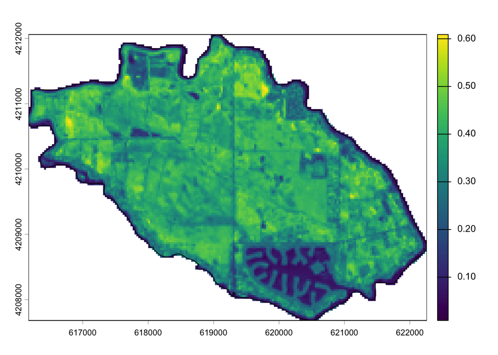

```r
b5_sub <- mask(b5_sub, mask = bethel)

plot(b5_sub)
plot(st_geometry(bethel), add = TRUE)
```

## Extract Data

Values can be extracted from individual locations (or sets of locations) using `extract()`. This can take a set of coordinates in matrix form, or use a Spatial* object. To get the reflectance value at 615000 E, 4199000 N:

```r
extract(b5, cbind(615000,4199000))
```

```
##   LC08_044034_20170614_B5
## 1               0.2121801
```

You can also extract for multiple locations. Let’s generate a set of random points in Bethel Island, and then sample the reflectance value for each of these.

```r
random_pnts <- st_sample(bethel, size = 20)

extract(b5, st_coordinates(random_pnts))
```

```
##    LC08_044034_20170614_B5
## 1                0.2389846
## 2                0.4003751
## 3                0.2679143
## 4                0.4048642
## 5                0.3086414
## 6                0.4406251
## 7                0.4356372
## 8                0.4042786
## 9                0.5084820
## 10               0.2565723
## 11               0.3791874
## 12               0.2978849
## 13               0.4845185
## 14               0.4030425
## 15               0.3853030
## 16               0.2651818
## 17               0.3476770
## 18               0.4205652
## 19               0.4857546
## 20               0.4741740
```

You can also extract values within a polygon, by replacing the point coordinates with a `sf` polygon:

```r
b5_bethel <- extract(b5, bethel)

head(b5_bethel)
```

```
##   ID LC08_044034_20170614_B5
## 1  1              0.10251180
## 2  1              0.08084705
## 3  1              0.05189565
## 4  1              0.17219034
## 5  1              0.29502234
## 6  1              0.31579795
```

By default, this returns the value of all pixels within the polygon. By adding the `fun=` argument, you can easily calculate summary statistics:

```r
extract(b5, bethel, fun = 'median')
```

```
##   ID LC08_044034_20170614_B5
## 1  1               0.3779947
```

Note that if the `sf` object has multiple polygons, it will return the summary statistic for each one. Let’s now extract the values for a different place (Oakley), and then we can compare them. We do this in a couple of steps. First get the polygon for Oakley, then extract using the two polygons combined.

```r
oakley = subset(ca_places, NAME == "Oakley")

b5_bethel_oakley <- extract(b5, rbind(bethel, oakley))

names(b5_bethel_oakley) <- c("ID", "B5")
```

We’ll visualize the difference with **ggplot2**, which shows higher NIR reflectance values for Bethel, likely indicating higher vegetation cover.

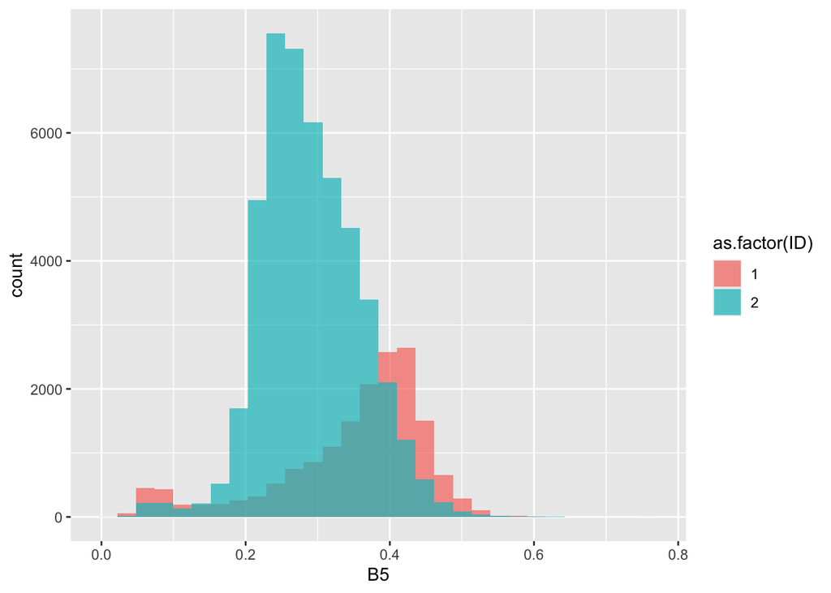

```r
ggplot(b5_bethel_oakley, aes(x = B5, fill = as.factor(ID))) +
  geom_histogram(alpha = 0.7, position = 'identity')
```

# Raster Stacks

```r
# Blue
b2 <- rast('./data/rs/LC08_044034_20170614_B2.tif')
# Green
b3 <- rast('./data/rs/LC08_044034_20170614_B3.tif')
# Red
b4 <- rast('./data/rs/LC08_044034_20170614_B4.tif')
# Near Infrared (NIR)
b5 <- rast('./data/rs/LC08_044034_20170614_B5.tif')
```

Now we’ll create a raster stack with all 4 of these:

```r
s <- c(b5, b4, b3, b2)

s
```

```
## class       : SpatRaster
## size        : 1245, 1497, 4  (nrow, ncol, nlyr)
## resolution  : 30, 30  (x, y)
## extent      : 594090, 639000, 4190190, 4227540  (xmin, xmax, ymin, ymax)
## coord. ref. : WGS 84 / UTM zone 10N (EPSG:32610)
## sources     : LC08_044034_20170614_B5.tif
##               LC08_044034_20170614_B4.tif
##               LC08_044034_20170614_B3.tif
##               LC08_044034_20170614_B2.tif
## names       : LC08_04~0614_B5, LC08_04~0614_B4, LC08_04~0614_B3, LC08_04~0614_B2
## min values  :        0.000846,        0.020841,        0.042592,         0.07484
## max values  :        1.012432,        0.786177,         0.69247,        0.717756
```

The metadata now shows that this contains 4 layers. You can also make the stack directly by passing a list of file names:

```r
filenames <- paste0('./data/rs/LC08_044034_20170614_B', 1:11, ".tif")

landsat <- rast(filenames)

landsat
```

```
## class       : SpatRaster
## size        : 1245, 1497, 11  (nrow, ncol, nlyr)
## resolution  : 30, 30  (x, y)
## extent      : 594090, 639000, 4190190, 4227540  (xmin, xmax, ymin, ymax)
## coord. ref. : WGS 84 / UTM zone 10N (EPSG:32610)
## sources     : LC08_044034_20170614_B1.tif
##               LC08_044034_20170614_B2.tif
##               LC08_044034_20170614_B3.tif
##               ... and 8 more sources
## names       : LC08_~14_B1, LC08_~14_B2, LC08_~14_B3, LC08_~14_B4, LC08_~14_B5, LC08_~14_B6, ...
## min values  :    0.096418,     0.07484,    0.042592,    0.020841,    0.000846,   -0.007872, ...
## max values  :    0.734628,    0.717756,     0.69247,    0.786177,    1.012432,    1.043205, ...
```

This now contains all bands representing reflection intensity in the following wavelengths: Ultra Blue, Blue, Green, Red, Near Infrared (NIR), Shortwave Infrared (SWIR) 1, Shortwave Infrared (SWIR) 2, Panchromatic, Cirrus, Thermal Infrared (TIRS) 1, Thermal Infrared (TIRS) 2.

If we now use the `extract()` function with this object, it will return values for all bands in the stack:

```r
extract(landsat, cbind(615000,4199000))
```

```
##   LC08_044034_20170614_B1 LC08_044034_20170614_B2 LC08_044034_20170614_B3
## 1               0.1691325               0.1547111               0.1395956
##   LC08_044034_20170614_B4 LC08_044034_20170614_B5 LC08_044034_20170614_B6
## 1               0.1370149               0.2121801               0.1594604
##   LC08_044034_20170614_B7 LC08_044034_20170614_B8 LC08_044034_20170614_B9
## 1               0.1526508              0.09177701             0.001236123
##   LC08_044034_20170614_B10 LC08_044034_20170614_B11
## 1                 311.6736                  308.671
```

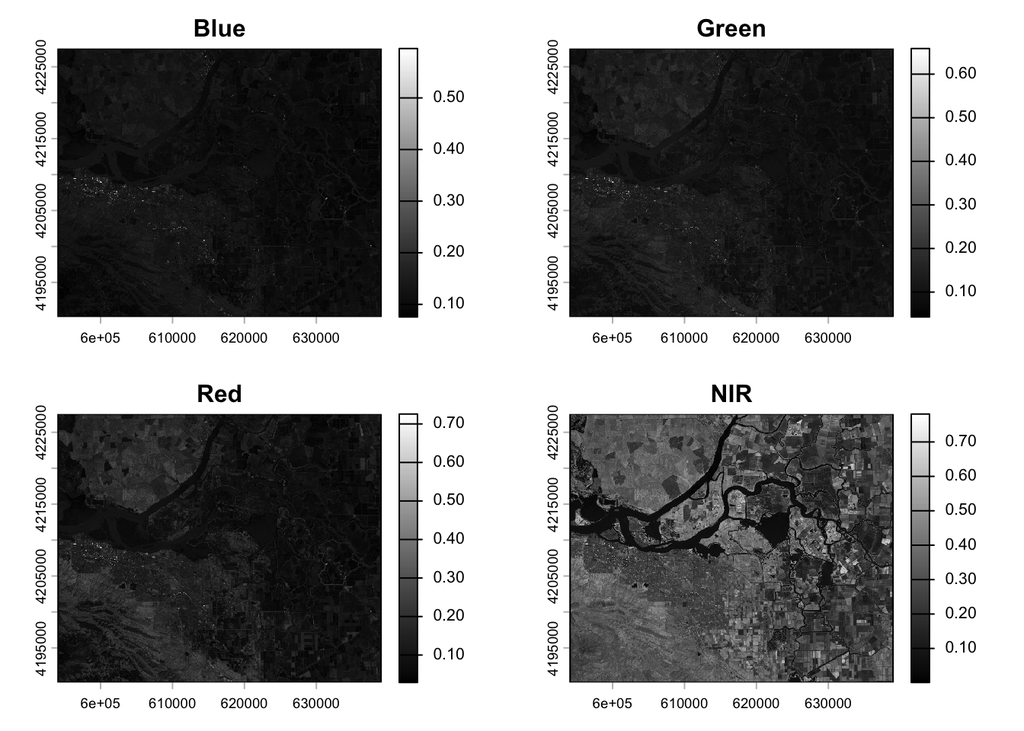

```r
par(mfrow = c(2,2))
plot(b2, main = "Blue", col = gray(0:100 / 100))
plot(b3, main = "Green", col = gray(0:100 / 100))
plot(b4, main = "Red", col = gray(0:100 / 100))
plot(b5, main = "NIR", col = gray(0:100 / 100))
```